# Bivariate Data

Monika Peteva Petkova

mpetevap@uni-sofia.bg, monikapetevapetkova@gmail.com

2021

In this section we review the relationship between 2 variables.

### Bivariate categorical data

We use the same functions as in the case of one categorical variable.

Let’s say we want to evaluate if the students who smoke study less?

And we have the following data for the `smoke` and `amount` variables. Where amount is presented as follows:  
1 - less than 5 hours of studying;  
2 - 5 - 10 hours of studying;  
3 - more than 10 hours of studying.

```r
> smokes <- c("Yes", "No", "No", "Yes", "No", "Yes", "Yes", "Yes", "No", "Yes")
> amount <- c(1, 2, 2, 3, 3, 1, 2, 1, 3, 2)
> table(smokes, amount)
      amount
smokes 1 2 3
   No  0 2 2
   Yes 3 2 1
```

Let’s review the proportions.

To see it clearer we set the numbers to be rounded to $3$

```r
> options(digits = 3)
```

We can calculate proportions using the `prop.table` function or the conditional proportions using:  
`1` means that the proportions in the rows will sum to $1$  
`2` means that the proportions in the columns will sum to $1$

```r
> prop.table(table(smokes, amount))
      amount
smokes   1   2   3
   No  0.0 0.2 0.2
   Yes 0.3 0.2 0.1
> prop.table(table(smokes, amount), 1)
      amount
smokes     1     2     3
   No  0.000 0.500 0.500
   Yes 0.500 0.333 0.167
> prop.table(table(smokes, amount), 2)
      amount
smokes     1     2     3
   No  0.000 0.500 0.667
   Yes 1.000 0.500 0.333
```

Another example

```r
> hair <- c("blond", "blond", "black", "blond", "brown", "brown",
+          "brown", "brown", "black", "brown", "black", "brown",
+          "black", "black", "black", "brown", "brown", "brown",
+          "brown", "brown", "black", "brown", "black", "brown",
+          "blond", "blond", "black", "blond", "brown", "brown",
+          "brown", "brown", "black", "brown", "black", "brown",
+          "brown", "brown", "black", "brown", "black", "brown",
+          "blond", "blond", "black", "blond", "brown", "brown")
> eyes <- c("blue", "green", "brown",  "blue", "green", "brown",
+          "brown", "black", "black", "green", "brown", "brown",
+          "green", "black", "black", "brown", "brown", "black",
+          "green", "black", "black", "brown", "brown", "black",
+          "brown",  "blue", "green", "brown", "brown", "black",
+          "black", "green", "brown",  "blue", "green", "brown",
+          "brown", "black", "brown",  "blue", "green", "brown",
+          "blue", "green", "brown",  "blue", "green", "brown")
```

```r
> table(hair, eyes)
       eyes
hair    black blue brown green
  black     4    0     6     4
  blond     0    5     2     2
  brown     7    2    11     5
> prop.table(table(hair, eyes))
       eyes
hair     black   blue  brown  green
  black 0.0833 0.0000 0.1250 0.0833
  blond 0.0000 0.1042 0.0417 0.0417
  brown 0.1458 0.0417 0.2292 0.1042
> prop.table(table(hair, eyes), 1)
       eyes
hair    black  blue brown green
  black 0.286 0.000 0.429 0.286
  blond 0.000 0.556 0.222 0.222
  brown 0.280 0.080 0.440 0.200
> prop.table(table(hair, eyes), 2)
       eyes
hair    black  blue brown green
  black 0.364 0.000 0.316 0.364
  blond 0.000 0.714 0.105 0.182
  brown 0.636 0.286 0.579 0.455
```

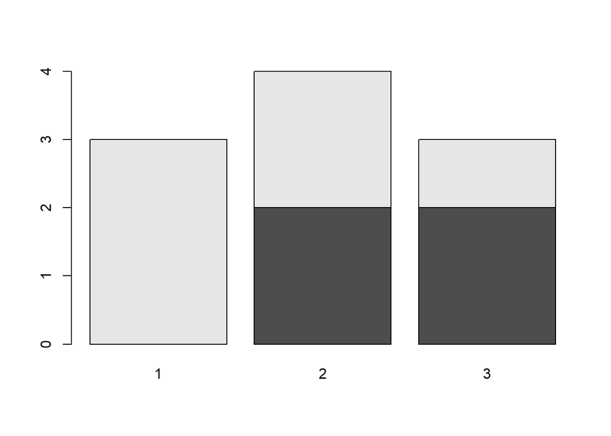

```r
> barplot(table(smokes, amount))
```

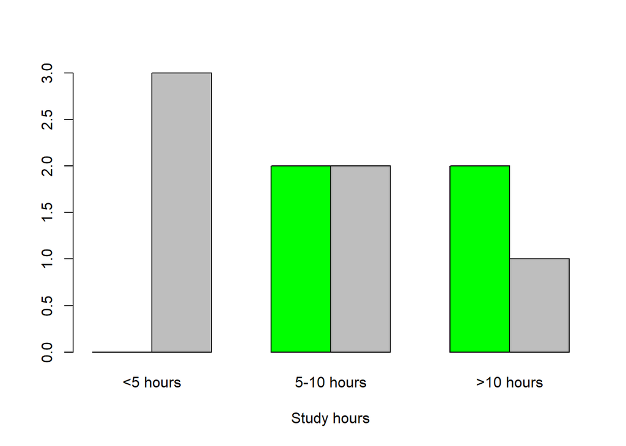

```r
> barplot(table(smokes, amount),
+         names.arg = c("<5 hours", "5-10 hours", ">10 hours"),
+         beside = TRUE,
+         col = c("Green", "Grey"),
+         xlab = "Study hours")
```

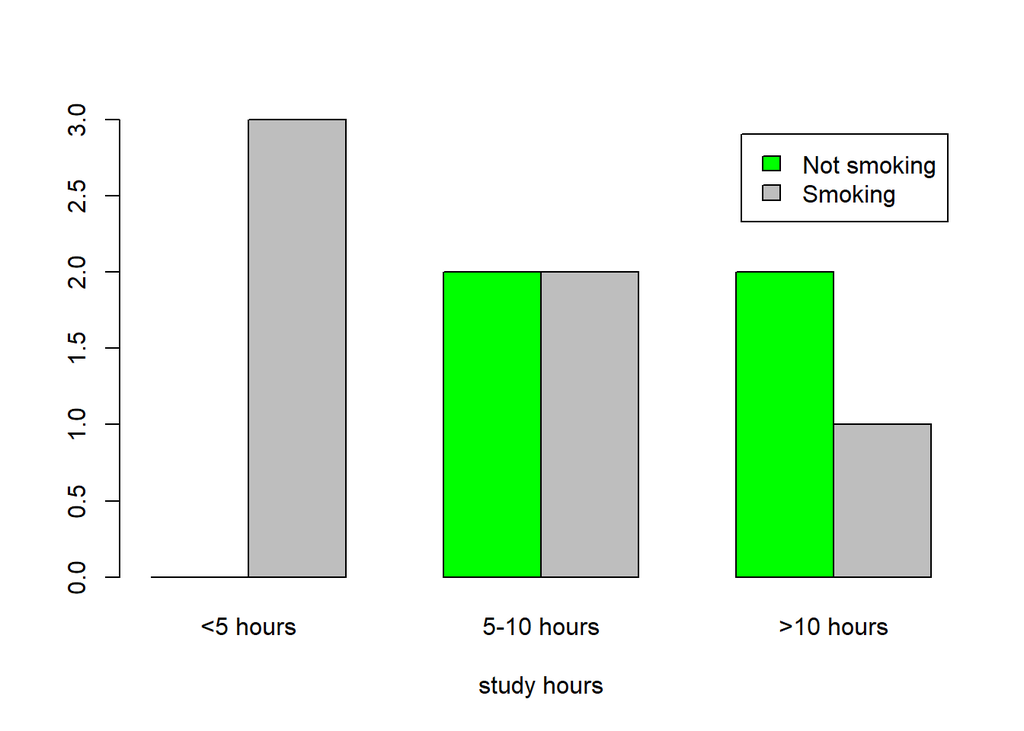

```r
> barplot(table(smokes,amount),
+         names.arg = c("<5 hours", "5-10 hours", ">10 hours"),
+         legend.text = c("Not smoking", "Smoking"),
+         beside = TRUE,
+         col = c("Green", "Grey"),
+         xlab = "study hours")
```

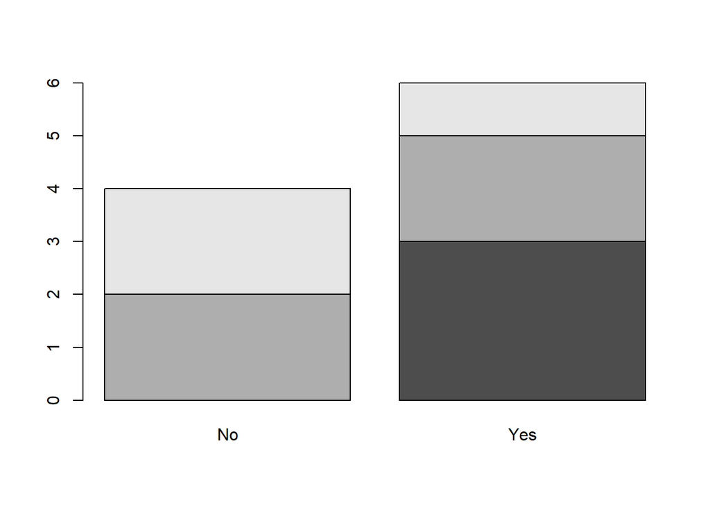

```r
> barplot(table(amount, smokes))
```

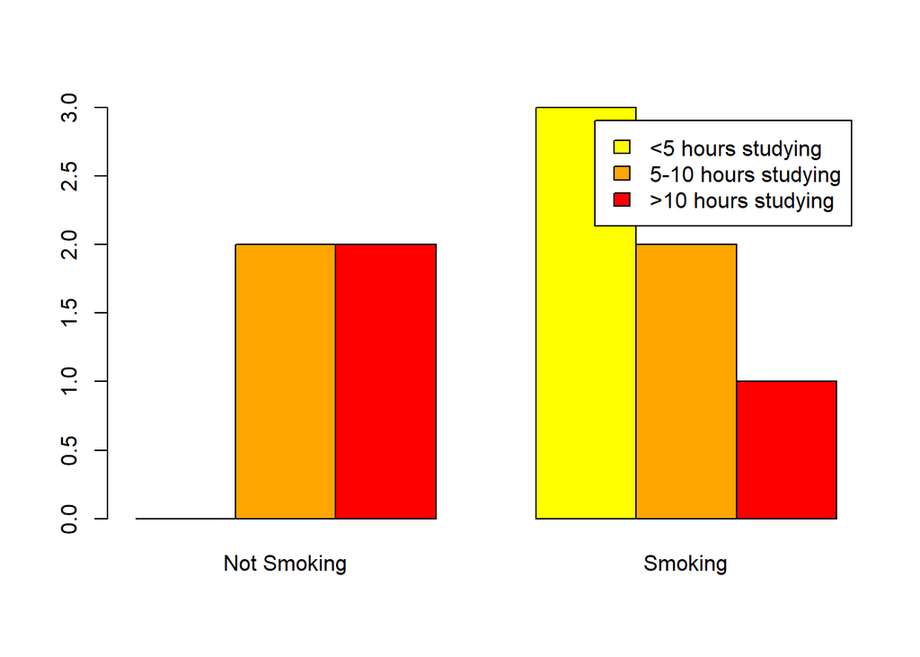

```r
> barplot(table(amount,smokes),
+         names.arg = c("Not Smoking", "Smoking"),
+         legend.text = c("<5 hours studying","5-10 hours studying",">10 hours studying"),
+         beside = TRUE,
+         col = c("Yellow", "Orange", "Red"))
```

### Categorical vs. numerical data

Simple example might be a drug test, where you have data for an experimental group and for a control group

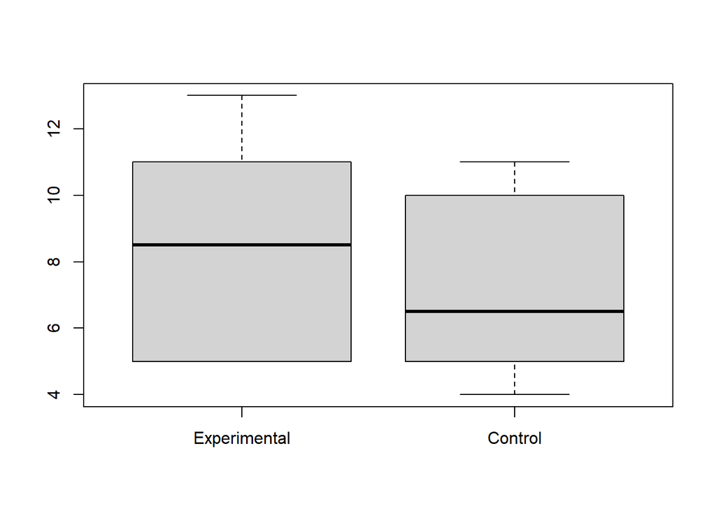

```r
> group.experimental <- c(5, 5, 5, 13, 7, 11, 11, 9, 8, 9)
> group.control <- c(11, 8, 4, 5, 9, 5, 10, 5, 4, 10)
> boxplot(group.experimental, group.control,
+         names = c("Experimental", "Control"))
```

From the plot we see that the control group has smaller observations than the experimental group.

Another example will be if we have the same data, but structured differently. Here we can use the `response ~ predictor`, which will break up the values in response, by the categories in category

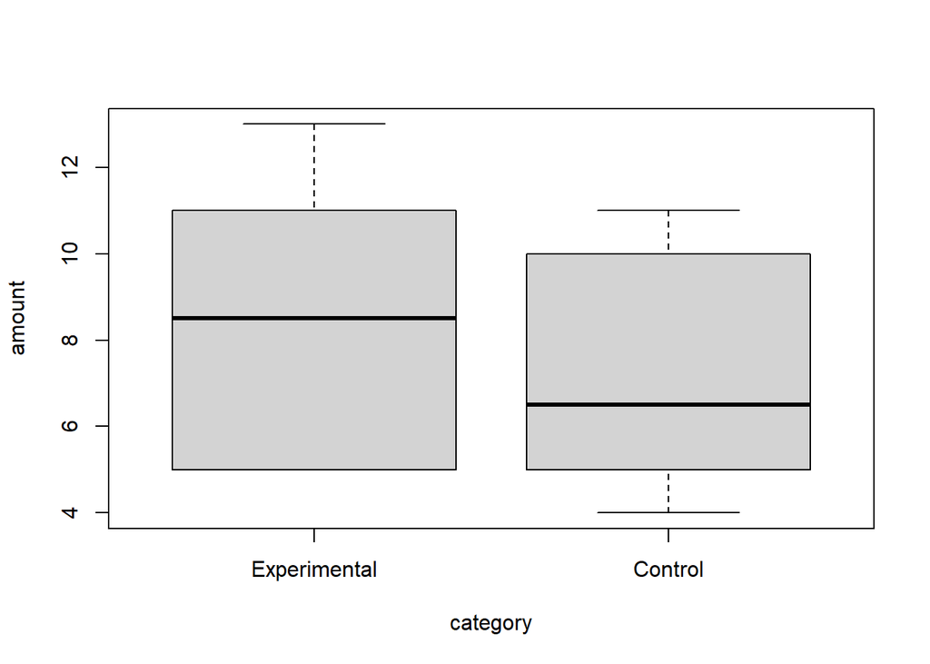

```r
> amount = c(5, 5, 5, 13, 7, 11, 11, 9, 8, 9, 11, 8, 4, 5, 9, 5, 10, 5, 4, 10)
> category = c(1, 1, 1, 1, 1, 1, 1, 1, 1, 1, 2, 2, 2, 2, 2, 2, 2, 2, 2, 2)
> boxplot(amount ~ category,
+         names = c("Experimental", "Control"))
```